# Part I - (Ford GoBike System Data)

## by (Oluwatosin Olanrewaju)

# Introduction

> This is an investigation of the variables of the Ford GoBike System Data is explored covering the greater San Francisco Bay area, visualizing interesting variables to see there impact on other variables.

## Preliminary Wrangling

```python
# importing all packages, set plots to be embedded inline
import numpy as np
import pandas as pd
import matplotlib.pyplot as plt
import seaborn as sb
import datetime

%matplotlib inline
```

> Load in your dataset and describe its properties through the questions below. Try and motivate your exploration goals through this section.

```python
bike_data = pd.read_csv('201902-fordgobike-tripdata.csv') #loading the dataset of ford_bikes
```

```python
bike_data.head()
```

|  | duration_sec | start_time | end_time | start_station_id | start_station_name | start_station_latitude | start_station_longitude | end_station_id | end_station_name | end_station_latitude | end_station_longitude | bike_id | user_type | member_birth_year | member_gender | bike_share_for_all_trip |
| --- | --- | --- | --- | --- | --- | --- | --- | --- | --- | --- | --- | --- | --- | --- | --- | --- |
| 0 | 52185 | 2019-02-28 17:32:10.1450 | 2019-03-01 08:01:55.9750 | 21.0 | Montgomery St BART Station (Market St at 2nd St) | 37.789625 | -122.400811 | 13.0 | Commercial St at Montgomery St | 37.794231 | -122.402923 | 4902 | Customer | 1984.0 | Male | No |
| 1 | 42521 | 2019-02-28 18:53:21.7890 | 2019-03-01 06:42:03.0560 | 23.0 | The Embarcadero at Steuart St | 37.791464 | -122.391034 | 81.0 | Berry St at 4th St | 37.775880 | -122.393170 | 2535 | Customer | NaN | NaN | No |
| 2 | 61854 | 2019-02-28 12:13:13.2180 | 2019-03-01 05:24:08.1460 | 86.0 | Market St at Dolores St | 37.769305 | -122.426826 | 3.0 | Powell St BART Station (Market St at 4th St) | 37.786375 | -122.404904 | 5905 | Customer | 1972.0 | Male | No |
| 3 | 36490 | 2019-02-28 17:54:26.0100 | 2019-03-01 04:02:36.8420 | 375.0 | Grove St at Masonic Ave | 37.774836 | -122.446546 | 70.0 | Central Ave at Fell St | 37.773311 | -122.444293 | 6638 | Subscriber | 1989.0 | Other | No |
| 4 | 1585 | 2019-02-28 23:54:18.5490 | 2019-03-01 00:20:44.0740 | 7.0 | Frank H Ogawa Plaza | 37.804562 | -122.271738 | 222.0 | 10th Ave at E 15th St | 37.792714 | -122.248780 | 4898 | Subscriber | 1974.0 | Male | Yes |

```python
# high-level overview of data shape and composition
print(bike_data.shape)
print(bike_data.dtypes)
bike_data.head()
```

```
(183412, 16)
duration_sec                 int64
start_time                  object
end_time                    object
start_station_id           float64
start_station_name          object
start_station_latitude     float64
start_station_longitude    float64
end_station_id             float64
end_station_name            object
end_station_latitude       float64
end_station_longitude      float64
bike_id                      int64
user_type                   object
member_birth_year          float64
member_gender               object
bike_share_for_all_trip     object
dtype: object
```

|  | duration_sec | start_time | end_time | start_station_id | start_station_name | start_station_latitude | start_station_longitude | end_station_id | end_station_name | end_station_latitude | end_station_longitude | bike_id | user_type | member_birth_year | member_gender | bike_share_for_all_trip |
| --- | --- | --- | --- | --- | --- | --- | --- | --- | --- | --- | --- | --- | --- | --- | --- | --- |
| 0 | 52185 | 2019-02-28 17:32:10.1450 | 2019-03-01 08:01:55.9750 | 21.0 | Montgomery St BART Station (Market St at 2nd St) | 37.789625 | -122.400811 | 13.0 | Commercial St at Montgomery St | 37.794231 | -122.402923 | 4902 | Customer | 1984.0 | Male | No |
| 1 | 42521 | 2019-02-28 18:53:21.7890 | 2019-03-01 06:42:03.0560 | 23.0 | The Embarcadero at Steuart St | 37.791464 | -122.391034 | 81.0 | Berry St at 4th St | 37.775880 | -122.393170 | 2535 | Customer | NaN | NaN | No |
| 2 | 61854 | 2019-02-28 12:13:13.2180 | 2019-03-01 05:24:08.1460 | 86.0 | Market St at Dolores St | 37.769305 | -122.426826 | 3.0 | Powell St BART Station (Market St at 4th St) | 37.786375 | -122.404904 | 5905 | Customer | 1972.0 | Male | No |
| 3 | 36490 | 2019-02-28 17:54:26.0100 | 2019-03-01 04:02:36.8420 | 375.0 | Grove St at Masonic Ave | 37.774836 | -122.446546 | 70.0 | Central Ave at Fell St | 37.773311 | -122.444293 | 6638 | Subscriber | 1989.0 | Other | No |
| 4 | 1585 | 2019-02-28 23:54:18.5490 | 2019-03-01 00:20:44.0740 | 7.0 | Frank H Ogawa Plaza | 37.804562 | -122.271738 | 222.0 | 10th Ave at E 15th St | 37.792714 | -122.248780 | 4898 | Subscriber | 1974.0 | Male | Yes |

```python
bike_data.describe()
```

|  | duration_sec | start_station_id | start_station_latitude | start_station_longitude | end_station_id | end_station_latitude | end_station_longitude | bike_id | member_birth_year |
| --- | --- | --- | --- | --- | --- | --- | --- | --- | --- |
| count | 183412.000000 | 183215.000000 | 183412.000000 | 183412.000000 | 183215.000000 | 183412.000000 | 183412.000000 | 183412.000000 | 175147.000000 |
| mean | 726.078435 | 138.590427 | 37.771223 | -122.352664 | 136.249123 | 37.771427 | -122.352250 | 4472.906375 | 1984.806437 |
| std | 1794.389780 | 111.778864 | 0.099581 | 0.117097 | 111.515131 | 0.099490 | 0.116673 | 1664.383394 | 10.116689 |
| min | 61.000000 | 3.000000 | 37.317298 | -122.453704 | 3.000000 | 37.317298 | -122.453704 | 11.000000 | 1878.000000 |
| 25% | 325.000000 | 47.000000 | 37.770083 | -122.412408 | 44.000000 | 37.770407 | -122.411726 | 3777.000000 | 1980.000000 |
| 50% | 514.000000 | 104.000000 | 37.780760 | -122.398285 | 100.000000 | 37.781010 | -122.398279 | 4958.000000 | 1987.000000 |
| 75% | 796.000000 | 239.000000 | 37.797280 | -122.286533 | 235.000000 | 37.797320 | -122.288045 | 5502.000000 | 1992.000000 |
| max | 85444.000000 | 398.000000 | 37.880222 | -121.874119 | 398.000000 | 37.880222 | -121.874119 | 6645.000000 | 2001.000000 |

```python
bike_data.info()
```

```
<class 'pandas.core.frame.DataFrame'>
RangeIndex: 183412 entries, 0 to 183411
Data columns (total 16 columns):
duration_sec               183412 non-null int64
start_time                 183412 non-null object
end_time                   183412 non-null object
start_station_id           183215 non-null float64
start_station_name         183215 non-null object
start_station_latitude     183412 non-null float64
start_station_longitude    183412 non-null float64
end_station_id             183215 non-null float64
end_station_name           183215 non-null object
end_station_latitude       183412 non-null float64
end_station_longitude      183412 non-null float64
bike_id                    183412 non-null int64
user_type                  183412 non-null object
member_birth_year          175147 non-null float64
member_gender              175147 non-null object
bike_share_for_all_trip    183412 non-null object
dtypes: float64(7), int64(2), object(7)
memory usage: 22.4+ MB
```

### What is/are the main feature(s) of interest in your dataset?

> The duration of the trips in relation with the genders and user groups. Will the insights provide ways to make a user become a subscriber rather than a customer?

### What features in the dataset do you think will help support your investigation into your feature(s) of interest?

> The duration of trip, Genders, Age, Days of the week, and User type.

```python
# dropping all null values
bike_data.dropna(inplace=True)
bike_data.info()
```

```
<class 'pandas.core.frame.DataFrame'>
Int64Index: 174952 entries, 0 to 183411
Data columns (total 16 columns):
duration_sec               174952 non-null int64
start_time                 174952 non-null object
end_time                   174952 non-null object
start_station_id           174952 non-null float64
start_station_name         174952 non-null object
start_station_latitude     174952 non-null float64
start_station_longitude    174952 non-null float64
end_station_id             174952 non-null float64
end_station_name           174952 non-null object
end_station_latitude       174952 non-null float64
end_station_longitude      174952 non-null float64
bike_id                    174952 non-null int64
user_type                  174952 non-null object
member_birth_year          174952 non-null float64
member_gender              174952 non-null object
bike_share_for_all_trip    174952 non-null object
dtypes: float64(7), int64(2), object(7)
memory usage: 22.7+ MB
```

```python
# fixing the datatypes problems in the dataset.
bike_data.start_time = pd.to_datetime(bike_data.start_time)
bike_data.end_time = pd.to_datetime(bike_data.end_time)
bike_data.start_station_id = bike_data.start_station_id.astype(str)
bike_data.end_station_id = bike_data.end_station_id.astype(str)
bike_data.bike_id = bike_data.bike_id.astype(str)
bike_data.user_type = bike_data.user_type.astype('category')
bike_data.member_birth_year = bike_data.member_birth_year.astype(int) # easeir to deal with as an integer.
```

```python
# Exploring date
bike_data['t_month'] = bike_data['start_time'].dt.month_name()
bike_data['t_day'] = bike_data['start_time'].dt.day_name()
bike_data['t_hour'] = bike_data['start_time'].dt.hour
```

```python
bike_data['start_time'].dt.year.unique() #checking the unique year of report to get user age
```

```
array([2019])
```

```python
bike_data['member_age'] = 2019 - bike_data.member_birth_year #creating a new column member age

bike_data.drop(['start_time', 'end_time', 'member_birth_year',
             'start_station_longitude','start_station_latitude','end_station_longitude','end_station_latitude'],
            axis=1,inplace=True)
bike_data.head(3)
```

|  | duration_sec | start_station_id | start_station_name | end_station_id | end_station_name | bike_id | user_type | member_gender | bike_share_for_all_trip | t_month | t_day | t_hour | member_age |
| --- | --- | --- | --- | --- | --- | --- | --- | --- | --- | --- | --- | --- | --- |
| 0 | 52185 | 21.0 | Montgomery St BART Station (Market St at 2nd St) | 13.0 | Commercial St at Montgomery St | 4902 | Customer | Male | No | February | Thursday | 17 | 35 |
| 2 | 61854 | 86.0 | Market St at Dolores St | 3.0 | Powell St BART Station (Market St at 4th St) | 5905 | Customer | Male | No | February | Thursday | 12 | 47 |
| 3 | 36490 | 375.0 | Grove St at Masonic Ave | 70.0 | Central Ave at Fell St | 6638 | Subscriber | Other | No | February | Thursday | 17 | 30 |

```python
df = bike_data.copy() #Copying the dataset for further exploration and visualization
df.head()
```

|  | duration_sec | start_station_id | start_station_name | end_station_id | end_station_name | bike_id | user_type | member_gender | bike_share_for_all_trip | t_month | t_day | t_hour | member_age |
| --- | --- | --- | --- | --- | --- | --- | --- | --- | --- | --- | --- | --- | --- |
| 0 | 52185 | 21.0 | Montgomery St BART Station (Market St at 2nd St) | 13.0 | Commercial St at Montgomery St | 4902 | Customer | Male | No | February | Thursday | 17 | 35 |
| 2 | 61854 | 86.0 | Market St at Dolores St | 3.0 | Powell St BART Station (Market St at 4th St) | 5905 | Customer | Male | No | February | Thursday | 12 | 47 |
| 3 | 36490 | 375.0 | Grove St at Masonic Ave | 70.0 | Central Ave at Fell St | 6638 | Subscriber | Other | No | February | Thursday | 17 | 30 |
| 4 | 1585 | 7.0 | Frank H Ogawa Plaza | 222.0 | 10th Ave at E 15th St | 4898 | Subscriber | Male | Yes | February | Thursday | 23 | 45 |
| 5 | 1793 | 93.0 | 4th St at Mission Bay Blvd S | 323.0 | Broadway at Kearny | 5200 | Subscriber | Male | No | February | Thursday | 23 | 60 |

```python
df.info()
```

```
<class 'pandas.core.frame.DataFrame'>
Int64Index: 174952 entries, 0 to 183411
Data columns (total 13 columns):
duration_sec               174952 non-null int64
start_station_id           174952 non-null object
start_station_name         174952 non-null object
end_station_id             174952 non-null object
end_station_name           174952 non-null object
bike_id                    174952 non-null object
user_type                  174952 non-null category
member_gender              174952 non-null object
bike_share_for_all_trip    174952 non-null object
t_month                    174952 non-null object
t_day                      174952 non-null object
t_hour                     174952 non-null int64
member_age                 174952 non-null int64
dtypes: category(1), int64(3), object(9)
memory usage: 17.5+ MB
```

## Univariate Exploration

> In this section, I will investigate the distributions of some variables individually. In this section, I'm going to individualy investigate distributions of some variables, clean and check for possible relationships between variables.

**Exploring number of bicycle service users**

```python
# Checking for the types of users

df.user_type.unique()
```

```
[Customer, Subscriber]
Categories (2, object): [Customer, Subscriber]
```

```python
# Using Functions for the count.
def plotbar(df, var, h='title', normalize=True, rot=0, kind='bar', figsize=(16,6), log=False):
    plt.figure(figsize=(10,6))

    base_color = sb.color_palette()[0]
    ax = sb.countplot(data=df, x =var, color=base_color)

# adding annotations
    n_points = df.shape[0]
    cat_counts = df[var].value_counts()
    locs, labels = plt.xticks() # get the current tick locations and labels

# looping through each pair of locations and labels
    for loc, label in zip(locs, labels):

    # to get the text property for the label to get the correct count
        count = cat_counts[label.get_text()]
        pct_string = '{}'.format(count)

    # for an annotation below the top of the bar
        plt.text(loc, count-8, pct_string, va='top', ha='center', color = 'w', fontsize=12)


    plt.title(h)
    plt.yticks([])
    plt.xlabel(var)

# Showing the plot
    plt.show();
```

```python
# Using Function to show the percentage of variables
def pieplot (df, var, h='title', normalize=True, rot=0, kind='pie', figsize=(16,6), log=False):
    plt.figure(figsize=(10,6))
    sorted_counts = df[var].value_counts()
    plt.pie(sorted_counts, labels = sorted_counts.index, startangle = 90,
            counterclock = False, autopct='%1.2f%%');
    plt.axis('square')
    plt.title(h, fontsize=15);
```

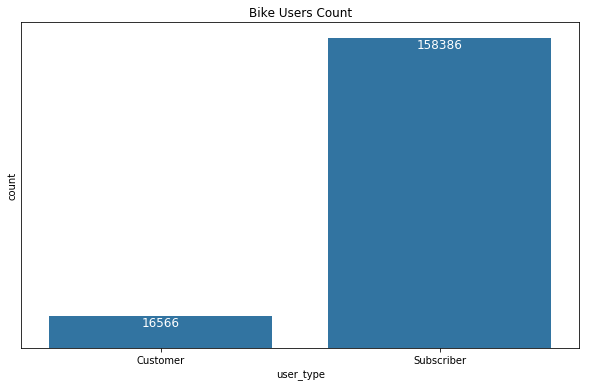

```python
#Plotting the total count of subscribers and customers
plotbar(df,'user_type', 'Bike Users Count')
```

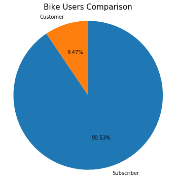

```python
pieplot(df,'user_type', 'Bike Users Comparison') #pie chart representation
```

From the visualisations above in the 2019 data of total entry of 174952 rows, more than three-quarter users is Subscribers 90.53%.

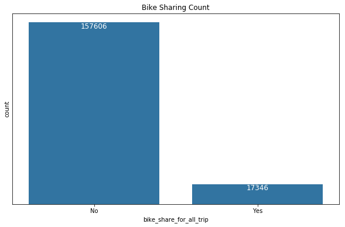

```python
#Plotting the total count of members willing to share their bikes
plotbar(df,'bike_share_for_all_trip', 'Bike Sharing Count')
```

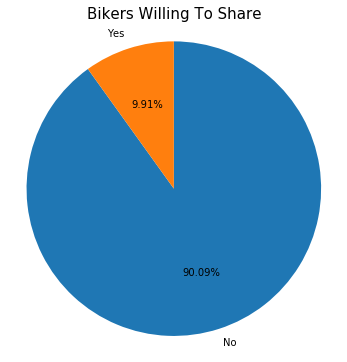

```python
pieplot(df,'bike_share_for_all_trip', 'Bikers Willing To Share') #pie chart representation
```

**The plots above shows only a few percentage (9.91%) are willing to share their bikes during trips.**

## Exploring the days variable.

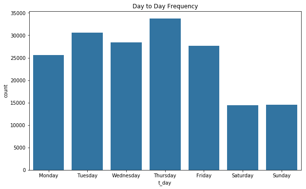

```python
# A countplot of bike usage based on days of the week
base_color = sb.color_palette()[0]
day_name = ["Monday","Tuesday","Wednesday","Thursday","Friday","Saturday","Sunday"]

plt.figure(figsize=(10,6))
plt.title('Day to Day Frequency')
sb.countplot(data=df, x='t_day', order=day_name, color=base_color);
```

Weekdays has way more trips than the weekends, the highest being Thursday then Tuesday.

## Checking the Hour counts.

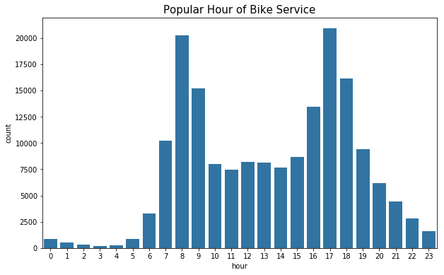

```python
hour_order = np.arange(0,24) #using the numpy arange function for ordering the hour

plt.figure(figsize=(10,6))
plt.title('Popular Hour of Bike Service', fontsize=15)
ax = sb.countplot(data=df, x='t_hour', order=hour_order, color=base_color)

plt.xlabel('hour');
```

Based on the plot above, the use of bicycle services peaks at 8 (8am) and 17 (5pm).

San Francisco tourists might want to use the Ford GoBike service and want trip around using the time slots.

## Trip Duration in seconds

```python
df.duration_sec.describe() #Average trip duration
```

```
count    174952.000000
mean        704.002744
std        1642.204905
min          61.000000
25%         323.000000
50%         510.000000
75%         789.000000
max       84548.000000
Name: duration_sec, dtype: float64
```

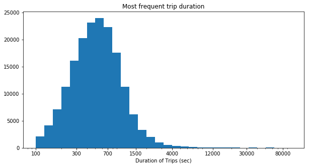

```python
# duration. Using numpy arange to create appropriate bins
bins = 10 ** np.arange(2, 5.0 + 0.1, 0.1)
plt.figure(figsize=[10, 5])
plt.hist(data=df, x='duration_sec', bins=bins)
ticks = [100, 300, 700 , 1500, 4000, 12000, 30000, 80000]
labels = ['{}'.format(val) for val in ticks]
plt.xscale('log')
plt.xticks(ticks, labels)
plt.xlabel('Duration of Trips (sec)')
plt.title('Most frequent trip duration')
plt.show();
```

The average trip duration of bike users is 704 secs and the plot above shows a rightly skewed distribution.